# Cardiovascular Disease

Diana, Daria, Luna Nguyen

11/14/2022

### Washington Cardiovascular Disease Death Statistics

For our project, we investigated a data set about the rates and trends of cardiovascular disease in the United States in search of possible risk factors or other power issues. We narrowed our data down to Washington state and discovered that the county with the highest deaths of 65+ year olds per 100,000 people was Adams in 2012 with 770 deaths, while the county with the lowest number of deaths per 100,000 people was San Juan in 2017 with 181 deaths. Additionally, the county with the least deaths of 35-64 year olds per 100,000 was Lewis in 2018 with 66 deaths, while the county with the lowest number of deaths of 35-64 year olds per 100,000 people was Asotin in 2005 with 12 deaths. We also found that the county with the highest percent change in death rate in 2010-2019 was Cowlitz with a percentage of 144 and the county with the lowest percentage change in death rate in 2010-2019 was Walla Walla with a percentage of -27.

### Overall Changes in Heart Disease and Stroke Death From 2000-2019

| County | avg_stroke_rate_change |
| --- | --- |
| Adams | 6 |
| Asotin | 10 |
| Benton | 8 |
| Chelan | 0 |
| Clallam | 39 |
| Clark | -5 |
| Columbia | 9 |
| Cowlitz | 30 |
| Douglas | -29 |
| Ferry | 0 |
| Franklin | -3 |
| Grant | 5 |
| Grays Harbor | 15 |
| Island | 19 |
| Jefferson | 8 |
| King | 12 |
| Kitsap | -7 |
| Kittitas | -11 |
| Klickitat | 10 |
| Lewis | 22 |
| Lincoln | 5 |
| Mason | 23 |
| Okanogan | 3 |
| Pacific | 8 |
| Pend Oreille | 2 |
| Pierce | 8 |
| San Juan | 5 |
| Skagit | 17 |
| Skamania | 10 |
| Snohomish | 3 |
| Spokane | -2 |
| Stevens | 1 |
| Thurston | 23 |
| Wahkiakum | 12 |
| Walla Walla | 14 |
| Whatcom | 31 |
| Whitman | 21 |
| Yakima | 30 |

I included a table of the overall changes in heart disease and stroke death from 2000-2019 because it can be helpful to analyze the changes in stroke and heart disease deaths over a period of time. It reveals that Clallam county has the biggest increase in those deaths while Douglas has the biggest decrease in deaths. Also, overall, most counties in Washington have had an increase in stroke and heart disease deaths, which will be helpful with our research question about how has cardiovascular disease and stroke fatalities changed overtime.

### Graphs About the Deaths Rates of 65+ Year Olds in Washington 2019

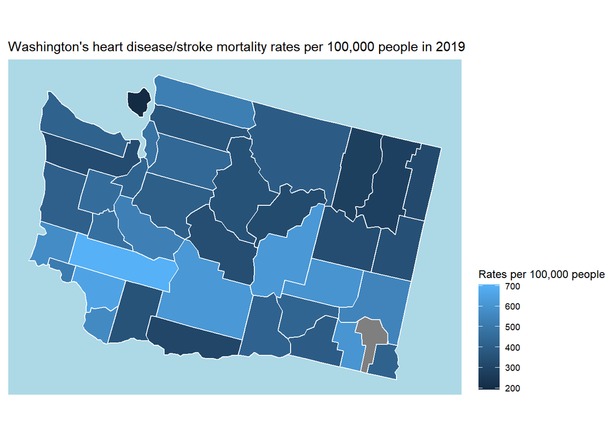

This map reveals the rates at which people die from heart disease and stroke per 100,000 people in each county. I included the chart because information about what counties have the highest and lowest rates are be easily seen with the bluest counties being the highest and the darkest being the lowest. It reveals counties where rates are highest and lowest. The southern counties seem to have the higher rates with Lewis county being the highest while the northern and northeastern counties have the lower rates. This data will be helpful in answering one of our research questions about why there are differences in rates, specifically if income is a factor.

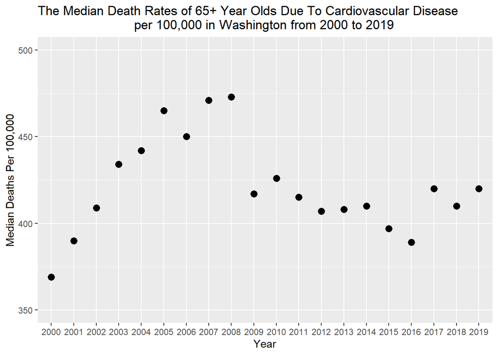

This is a scatter plot that shows the median deaths per 100,000 people for people ages 65+ in Washington over the span of 2000 to 2019. This scatter plot was created in hopes that it would reveal any significant changes in the median rates of death due to cardiovascular disease. We could then investigate these time ranges for more information about any potential risk factors or events that caused the significant decrease or increase in the median death rates. From the scatter plot we can see that in 2008 Washington had the highest median death rate. The years leading up to 2008 also have considerably high numbers compared to 2000. This scatter plot allows us to see that something happened between the years 2000 and 2008 that caused a large increase. Additionally, we can see that after 2008, the median death rates slowly starting dropping below 400 before rising above again in 2017. Both these time ranges should be further investigated because there may be underlying events that caused these fluctuations, like how Washington State implemented a sugar tax.

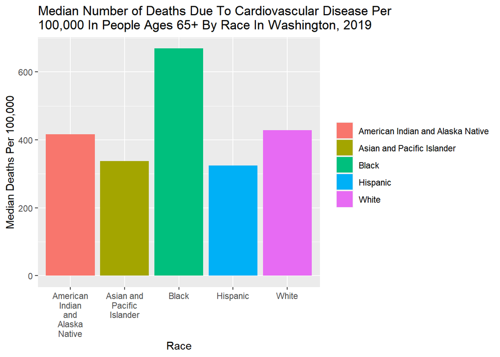

This is a bar graph that shows the median number of deaths of 65+ year olds per 100,000 people in Washington during the year 2019. We created this bar graph because we wanted to assess if race had any influence on the risk on dying to cardiovascular disease. Our bar graph shows Black people are the number one race that died from cardiovascular disease. The graph shows that they die SIGNIFICANTLY more than any other race. However, this may be due to there being a small amount of observations on Black people in our data set. For the 2nd most deaths, White people and American Indian and Alaska Native are a close tie but White people are a little higher. For the races with the least cardiovascular disease death Hispanic and Asian and Pacific Islander are a close tie with Asian and Pacific Islander being slightly higher.

Perhaps if we took data from all over the world instead of just Washington, we would have reached a different conclusion. However, our graph does reveal to us that there seems to be a possible risk factor for Black people and a slight disparity in the death rates of White people that should be investigated further.

*The correct term for American Indian is indigenous people